# CHAVA_SAI_VIVEK_INTERPRETATION

Sai Vivek Chava

2023-12-12

```r
library(tidyverse, tidymodels)
library(caret)
df <- readr::read_csv("paint_project_train_data.csv", col_names = TRUE, show_col_types = F)
df %>% glimpse()
```

```
## Rows: 835
## Columns: 8
## $ R          <dbl> 172, 26, 172, 28, 170, 175, 90, 194, 171, 122, 0, 88, 144, …
## $ G          <dbl> 58, 88, 94, 87, 66, 89, 78, 106, 68, 151, 121, 140, 82, 163…
## $ B          <dbl> 62, 151, 58, 152, 58, 65, 136, 53, 107, 59, 88, 58, 132, 50…
## $ Lightness  <chr> "dark", "dark", "dark", "dark", "dark", "dark", "dark", "da…
## $ Saturation <chr> "bright", "bright", "bright", "bright", "bright", "bright",…
## $ Hue        <dbl> 4, 31, 8, 32, 5, 6, 34, 10, 1, 21, 24, 22, 36, 16, 26, 12, …
## $ response   <dbl> 12, 10, 16, 10, 11, 16, 10, 19, 14, 25, 14, 19, 14, 38, 15,…
## $ outcome    <dbl> 1, 1, 1, 0, 0, 0, 0, 0, 0, 0, 0, 0, 0, 0, 0, 0, 0, 0, 1, 1,…
```

```r
dfii <- df %>%
  mutate(y = boot::logit( (response - 0) / (100 - 0) ) ) %>%
  select(R, G, B,
         Lightness, Saturation, Hue,
         y, outcome)

dfii %>% glimpse()
```

```
## Rows: 835
## Columns: 8
## $ R          <dbl> 172, 26, 172, 28, 170, 175, 90, 194, 171, 122, 0, 88, 144, …
## $ G          <dbl> 58, 88, 94, 87, 66, 89, 78, 106, 68, 151, 121, 140, 82, 163…
## $ B          <dbl> 62, 151, 58, 152, 58, 65, 136, 53, 107, 59, 88, 58, 132, 50…
## $ Lightness  <chr> "dark", "dark", "dark", "dark", "dark", "dark", "dark", "da…
## $ Saturation <chr> "bright", "bright", "bright", "bright", "bright", "bright",…
## $ Hue        <dbl> 4, 31, 8, 32, 5, 6, 34, 10, 1, 21, 24, 22, 36, 16, 26, 12, …
## $ y          <dbl> -1.9924302, -2.1972246, -1.6582281, -2.1972246, -2.0907411,…
## $ outcome    <dbl> 1, 1, 1, 0, 0, 0, 0, 0, 0, 0, 0, 0, 0, 0, 0, 0, 0, 0, 1, 1,…
```

```r
cols_num <- c("R", "G", "B", "Hue")
var_mean <- as.vector(apply(df[,cols_num], 2, mean))
var_sd <- as.vector(apply(df[,cols_num], 2, sd))
df_stan  <- df[,cols_num] %>% scale(center = var_mean, scale = var_sd) %>%
  as.data.frame() %>% tibble::as_tibble() %>% bind_cols(dfii[,c('Lightness', 'Saturation', 'y')])

df_stan %>% glimpse()
```

```
## Rows: 835
## Columns: 7
## $ R          <dbl> -0.19790120, -2.74419521, -0.19790120, -2.70931447, -0.2327…
## $ G          <dbl> -2.3619736, -1.7631189, -1.6433480, -1.7830807, -2.2022790,…
## $ B          <dbl> -1.7994266, -0.1706872, -1.8726283, -0.1523868, -1.8726283,…
## $ Hue        <dbl> -1.3548215, 1.3198239, -0.9585777, 1.4188848, -1.2557605, -…
## $ Lightness  <chr> "dark", "dark", "dark", "dark", "dark", "dark", "dark", "da…
## $ Saturation <chr> "bright", "bright", "bright", "bright", "bright", "bright",…
## $ y          <dbl> -1.9924302, -2.1972246, -1.6582281, -2.1972246, -2.0907411,…
```

**With the model training completed, you can now answer meaningful questions associated with the data!**

**You must identify the best regression model and the best classification model.**

##### Classification:

The model formula is **y ~ R+G+B+Hue+Lightness+Saturation**

So, based on the observation, we can tell that `XGB` seemed to perform better overall is considered the best model.

##### Regression

Based on the training set performance, it is observed that `XGB` seems to perform better followed by the `MARS` in terms of MSE, MAE and R-squared and closely followed by `lm_cat_interaction`.

When tested on the test set, `lm_cat_interaction` seemed to perform better with the leasr `MSE` and `RMSE` scores followed by `XGB`.

As the difference between the training set performance and test set performance is not much, so, considering `lm_cat_interaction` as best.

The model formula is **y~ Saturation*(R+G+B+Hue)+ Lightness* (R+G+B+Hue)**

**Identify the most important variables associated with your best performing models.**

#### Classification Model

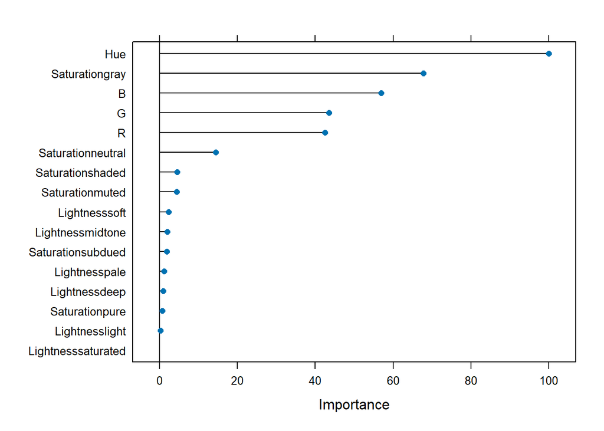

```r
best_cls_mod <- readr::read_rds("cls_mod_8.rds")
plot(varImp(best_cls_mod))
```

Per the variable importance observed from the plot above, `Hue` has the most importance followed by the `Saturation, Blue`. `G, R` has almost equal importance.

It can be interpreted as `HSL1` model hs importance in deciding the outcome for classification model.

#### Regression Model

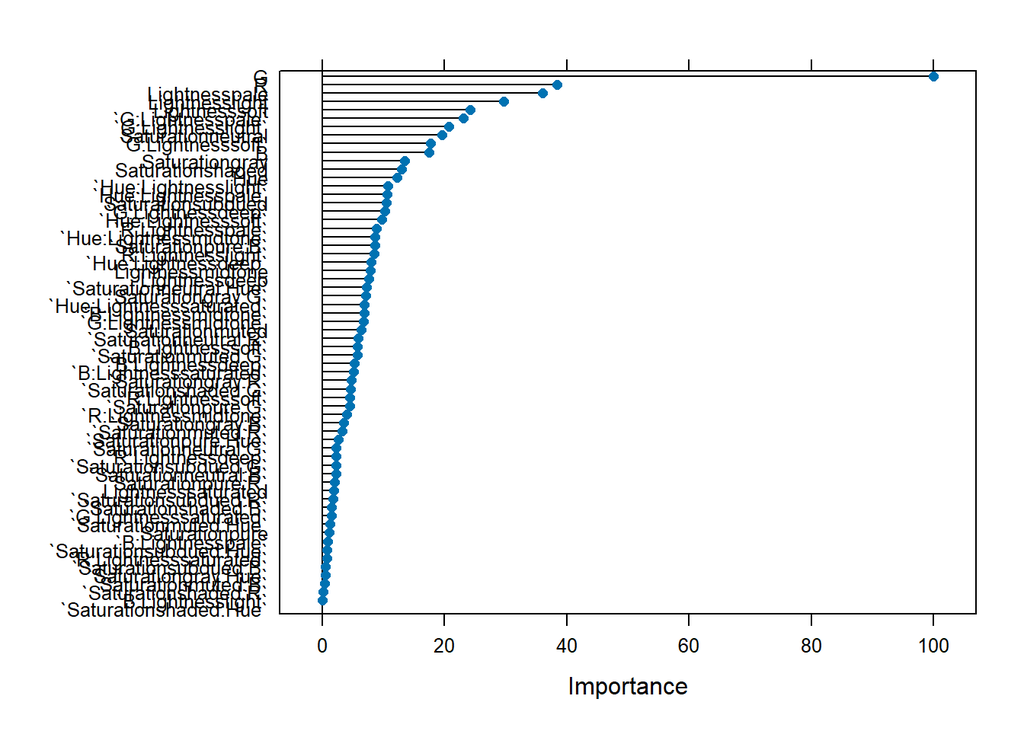

```r
best_reg_mod <- readr::read_rds("reg_mod_3.rds")
plot(varImp(best_reg_mod))
```

Per the plot above, it can be observed that, `G` is the most important variable followed by `R` and Levels of Lightness and it’s interaction with G and B.

It can be interpreted that RGB model has impact on the response variable.

**Are the most important variables similar for the regression and classification tasks?**

No, the important variable are different for each task.

**Does one of the color model INPUTS “dominate” the other variables**

As can be interpreted from the variable importance of the corresponding best models, and other models with decent predictions, Classifying outcome is potentially impacted by the `HSL` model and the regression of response is impacted by the `RGB` model.

**Does one of the color model INPUTS appear to be not helpful at all?**

There was no one color model input that is not helpful. As observed through the performance of the models created, Each and every model has inputs importance based on the model formula. But it is also observed that not all saturation levels are that important for most of the classification and regression tasks.

**Based on your modeling results, do you feel the color model INPUTS alone help identify POPULAR paints????**

Despite the fact that there seem to be a direct relationship between color models and outcomes in most of the cases, there seem to be somthing that’s a miss in the model. So, it can be said that the color model inputs alone won’t help us predict the popular paints.

### Input Insights

**You must drill down further to gain additional insights into the patterns of the data!**

**You must identify the combinations of Lightness and Saturation**

#### Visualizing the tougher customers

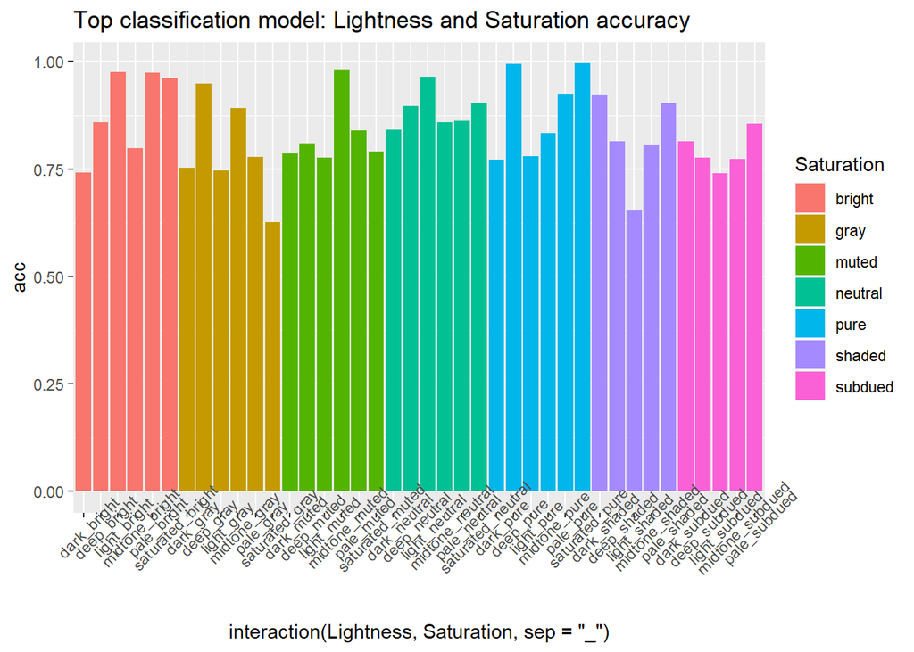

```r
df %>%
  select(Lightness, Saturation) %>%
  mutate(row_index = 1:nrow(.)) %>%
  inner_join(best_cls_mod$pred, by = c("row_index" = "rowIndex")) %>%
  select(
    Lightness,
    Saturation,
    pred,
    obs,
    event,
    non_event
  ) %>%
  group_by(Lightness, Saturation) %>%
  summarise(
    acc = sum(ifelse(obs == pred, 1, 0)) / n(),
    .groups = 'drop'
  ) %>%
  arrange(desc(acc)) %>%
  ggplot(mapping = aes(x = interaction(Lightness, Saturation, sep = "_"), y = acc, fill = Saturation)) +
  geom_col(position = "dodge") +
  ggtitle("Top classification model: Lightness and Saturation accuracy")+
  theme(axis.text.x = element_text(angle = 45))
```

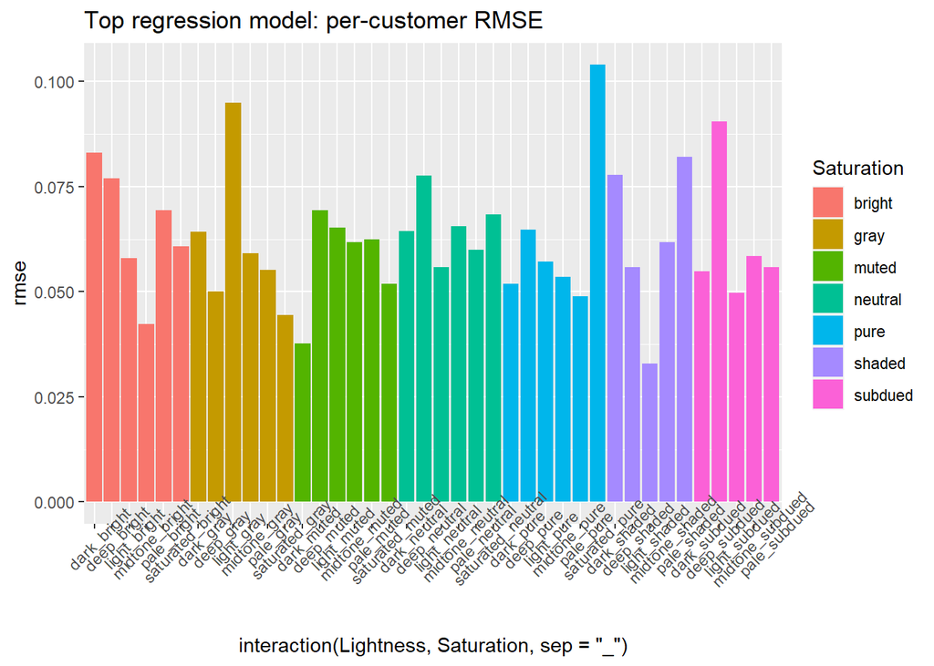

```r
dfii %>%
  select(Lightness, Saturation) %>%
  mutate(row_index = 1:nrow(.)) %>%
  inner_join(best_reg_mod$pred, by = c("row_index" = "rowIndex")) %>%
  select(
    Lightness,
    Saturation,
    pred,
    obs
  ) %>%
  group_by(Lightness, Saturation) %>%
  summarise(
    rmse = caret::RMSE(pred, obs),
    .groups = 'drop'
  ) %>%
  arrange(rmse) %>%
  ggplot(mapping = aes(x = interaction(Lightness, Saturation, sep = "_"), y = rmse, fill = Saturation)) +
  geom_col(position = "dodge") +
  ggtitle("Top regression model: per-customer RMSE") +
  theme(axis.text.x = element_text(angle = 45))
```

**That appear to be the HARDEST to predict in the regression and classification tasks**

Based on the plot above, The combinations of Lightness and Saturation

> In Classifiction: - The hardest to predict combinations are `Saturated - gray`, `light - shaded`. In Regression: - The hardest to predict comninations are `Saturated - pure` and `light - gray`, `dark - subdued`.

**That appear to be the EASIEST to predict in the regression and classification tasks**

Based on the plot above, The combinations of Lightness and Saturation

> In Classifiction: - The easiest to predict combinations are `Saturated - pure` , `Deep - pure`, `midtone - muted`, `light - bright, pale - bright` In Regression: - The easiest to predict comninations are `light - shaded`, `dark - muted, midtone - bright`.

```r
df_holdout <-readr::read_csv("paint_project_holdout_data.csv",
                             col_names = T,show_col_types = FALSE)

reg_preds <- predict(best_reg_mod, newdata = df_holdout)
cls_preds <- predict(best_cls_mod, newdata = df_holdout)

df_pred <- tibble::tibble( y = predict(best_reg_mod, newdata = df_holdout),
                            outcome = predict(best_cls_mod, newdata = df_holdout)) %>%
  bind_cols(predict(best_cls_mod, newdata = df_holdout, type = 'prob') %>%
      select(probability = event)) %>%
  tibble::rowid_to_column('id')

df_pred %>%readr::write_csv("df_final_preds.csv")
```

```r
df_shiny_metrics <- read.csv("metrics.csv")
df_shiny_metrics
```

```
##    .metric .estimator  .estimate
## 1     rmse   standard 0.06328526
## 2      rsq   standard 0.99724827
## 3      mae   standard 0.04585228
## 4 accuracy     binary 0.86255924
## 5     sens     binary 0.56886228
## 6     spec     binary 0.93500739
## 7  roc_auc     binary 0.88037220
```